# The enchanted die

## Prologue

In our modern world, we have left behind magic and myths, instead relying on facts and data. We embrace chance and are willing to accept that we cannot control the outcome of a die roll - as long as it is a fair die. But what if there was a way to influence chance with magic? What if we all still have magical powers, waiting to surface?

Imagine the potential you could unlock if we were to reclaim our magic abilities - and then someone comes along and tells you about regression to the mean. A coding journey.

## What this is all about

I will use my “magic powers” to enchant a die - which will improve its “performance”. In case you didn’t know, I have the ability to influence dice - better not get in my way during board games! In fact, I once did a [YouTube video](https://www.youtube.com/watch?v=LB_X3jXZC8I) demonstrating my magic powers, which was later picked up by the millions-of-subscriber German scicom YouTuber Dr. Mai Thi Nguyen-Kim in her [video about the placebo effect](https://www.youtube.com/watch?v=ESMooFO0aaY).

Anyways, here’s the `R` code I used to analyse and later generate some magical die roll data. Spoiler alert: Ultimately, I will show that I do not, in fact, possess magical powers. Sorry.

## Read and process the data

As you can see in my video, I actually rolled a die 200 times and “enchanted” it with my little wooden stick whenever I rolled a 1 or a 2. The logic behind that: Obviously, when the die’s performance is “low” (the larger the number, the better), it needs some “magical support”. The data is stored in this [GitHub repository](https://github.com/einGlasRotwein/blog).

```r
library(tidyverse)
library(effsize)
library(prmisc) # for printing the t-test

# plot theme
julis_theme <-
  theme(panel.background = element_rect(fill = "#cccccc"),
        panel.grid = element_blank(),
        plot.background = element_rect(fill = "#404040", colour = NA),
        axis.line = element_line(colour = "black"),
        legend.position = "none",
        plot.title = element_text(size = 14, face = "plain", hjust = .5, colour = "#ffffff"),
        axis.text = element_text(size = 12, colour = "#ffffff"),
        axis.title = element_text(size = 14, colour = "#ffffff"),
        strip.text = element_text(size = 12, colour = "#ffffff"),
        strip.background = element_rect(fill = "#303030"))

## load data
dd <- read.csv("enchanted_die.csv", sep = ";")
```

A quick look at the data shows us there is a column named `roll`, which indicates the number rolled. And then there’s `magic_before`, which tells us whethere magic “happened” before that roll. `1` means there was magic `0` means there wasn’t.

```r
head(dd) %>%
  kable() %>%
  kable_styling("basic")
```

| roll | magic_before |
| --- | --- |
| 3 | 0 |
| 2 | 0 |
| 5 | 1 |
| 6 | 0 |
| 1 | 0 |
| 4 | 1 |

Does the die get better after my “magical intervention”? We can find that out by calculating the difference to the previous run. For the first run, we insert a missing value, because there can’t be a difference to the previous run.

```r
dd$diff <- c(NA, diff(dd$roll))
head(dd) %>%
  kable() %>%
  kable_styling("basic")
```

| roll | magic_before | diff |
| --- | --- | --- |
| 3 | 0 | NA |
| 2 | 0 | -1 |
| 5 | 1 | 3 |
| 6 | 0 | 1 |
| 1 | 0 | -5 |
| 4 | 1 | 3 |

## Results

A sneak peak at the data shows us the differences in magic vs. no magic.

```r
by(dd$diff, dd$magic_before, summary)
```

```
## dd$magic_before: 0
##    Min. 1st Qu.  Median    Mean 3rd Qu.    Max.    NA's
## -5.0000 -2.0000 -1.0000 -0.9071  1.0000  3.0000       1
## ------------------------------------------------------------
## dd$magic_before: 1
##    Min. 1st Qu.  Median    Mean 3rd Qu.    Max.
##  -1.000   1.000   2.000   2.119   3.500   5.000
```

Descriptively, it looks like the die improves a lot after we’ve used magic - by 2.119 points on average! And it even gets worse when we don’t use magic: The number rolled decreases by 0.9071 on anverage. Here’s a little plot for that: The points represent the difference to the previous run for single runs. The large square in the middle is the mean value.

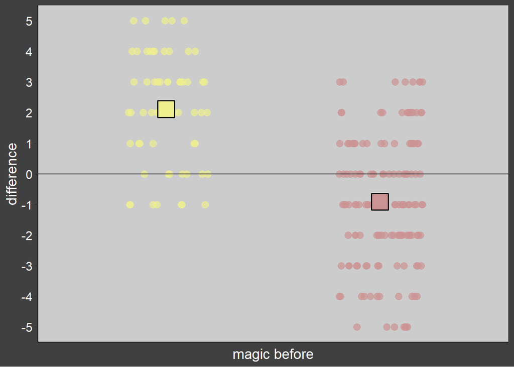

```r
dd %>%
  mutate(magic_before = ifelse(magic_before == 0, "no magic", "magic")) %>%
  ggplot(aes(x = factor(magic_before), y = diff, colour = factor(magic_before),
             fill = factor(magic_before))) +
  geom_point(position = position_jitter(width = .2, height = 0), alpha = .7, size = 3) +
  stat_summary(size = 2, fun = "mean", shape = 22, colour = "black") +
  geom_hline(yintercept = 0) +
  labs(y = "difference", x = "magic before") +
  scale_y_continuous(breaks = seq(-5, 5, 1)) +
  scale_colour_manual(values = c("#efef8f", "#cc9393")) +
  scale_fill_manual(values = c("#efef8f", "#cc9393")) +
  julis_theme +
  theme(axis.text.x = element_blank(),
        axis.ticks.x = element_blank())
```

Let’s check whether the die improves significantly when we use magic. And it does! $t(125.35) = -10.15$, $p < .001$, $d = -1.48$. The effect size is huge!

## How did that happen?

As you might have guessed, magic is not the reason for this result. Did I manipulate the die? It doesn’t look like it - the numbers I rolled are approximately uniformly distributed.

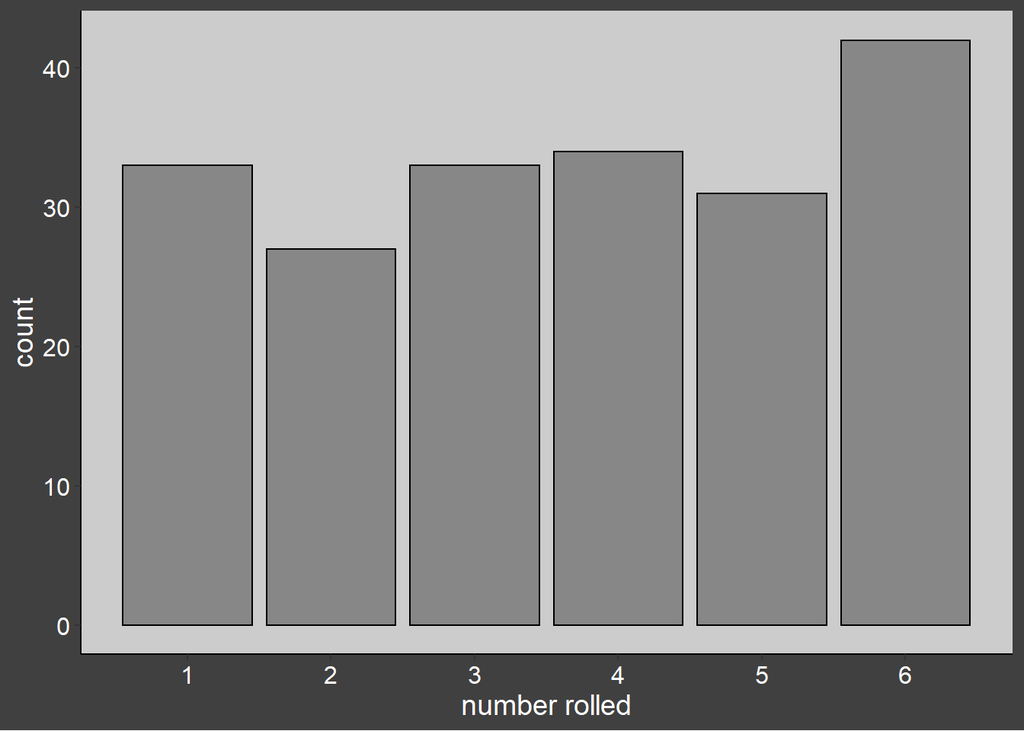

```r
dd %>%
  ggplot(aes(x = roll)) +
  geom_bar(col = "black", alpha = .6) +
  scale_x_continuous(breaks = seq(1, 6, 1)) +
  labs(x = "number rolled", y = "count") +
  julis_theme
```

Also, the numbers are uniformly distributed for both conditions “magic” and “no magic”:

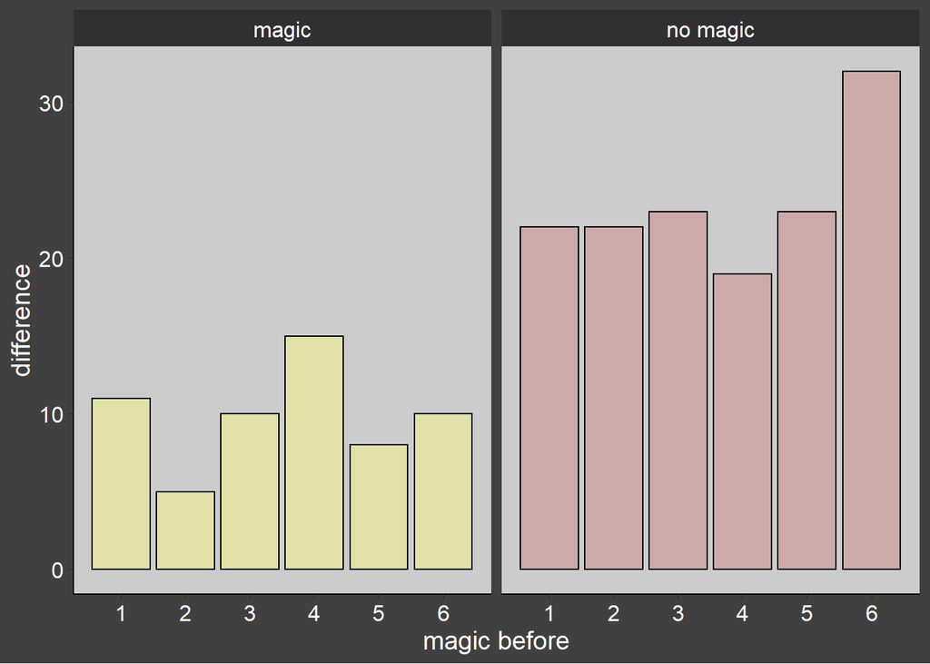

```r
dd %>%
  mutate(magic_before = ifelse(magic_before == 0, "no magic", "magic")) %>%
  ggplot(aes(x = roll, fill = magic_before)) +
  geom_bar(col = "black", alpha = .6) +
  scale_x_continuous(breaks = seq(1, 6, 1)) +
  labs(y = "difference", x = "magic before") +
  scale_fill_manual(values = c("#efef8f", "#cc9393")) +
  facet_wrap(~magic_before) +
  julis_theme
```

What is it, then? The poor die didn’t have a choice. I always use magic when I rolled a 1 or a 2. However, after I rolled a 1, the die can **only** “improve” - the only way is up (or it stays the same). After a 2, only one of six numbers would result in a “worse” performance: If I roll a 1. If I roll a 6, on the other hand, things can only get worse. So, because I use my magical intervention when the poor die is at his lowest, it can only improve afterwards.

## Regression to the mean

I use this little experiment as a demonstration for lay people, but if you are a scientist, you already know what happened here. This is a demonstration of “regression to the mean” in an extreme form. The die did not improve **because** I used magic, but because I used magic **at the right time**. Most people know this phenomenon from everyday life, when they say: “Well, it can’t get worse.” However, their intuition for it suddenly disappears in other areas: We are angry when our favourite football team loses after a stellar performance in the previous game. We are annoyed when the sequel of a film isn’t as good as the first one. And we (Germans) take homeopathic placebos when our pain is at peak levels and then think that it was the globuli that helped us.

## Simulated data

To illustrate the phenomenon further, here is a function that will generate “enchanted” die rolls. It generates `nrolls` die rolls and enchants them whenever a “magic number” (`magic_numbers`) has been rolled previously. If you like to play D&D, you can also specify the numbers the die can potentially roll via `die_outcomes` (e.g. numbers from 1-20).

```r
enchant_die <- function(nrolls, magic_numbers = c(1, 2), die_outcomes = 1:6) {

  # If at least one magic number cannot be rolled by the dice, throw an error.
  if (sum(!magic_numbers %in% die_outcomes) > 0) {
    stop("At least one of your magic numbers cannot be rolled by your die.")
  }

  dd <- data.frame(roll = sample(die_outcomes, nrolls, replace = TRUE),
                   magic_before = NA)

  dd$magic_before <- ifelse(lag(dd$roll) %in% magic_numbers, 1, 0)

  dd$magic_before[1] <- 0 # no magic in the first roll

  # Sende eine magische Nachricht, wenn die Funktion fertig ist.
  magic_message <- c("Mischief managed.", "Magical!", "Alea iacta est.", "You're a wizard!",
                     "Magic is in the air.", "Did you just feel that?", "Enchanting!",
                     "Thank you for choosing Enchanted Dies!", "I'm slightly bewichted.",
                     "With great power comes great responsibilty.", "That's a lot of die rolls",
                     "6 is my lucky number!", "Charming!", "I'm under your spell!")

  print(sample(magic_message, 1))

  return(dd)
}
```

Let’s generate 500 die rolls and use magic whenever a 5 or a 6 was rolled.

```r
dd <- enchant_die(500, magic_numbers = c(5, 6))
```

```
## [1] "I'm under your spell!"
```

We quickly run the same code as before to visualise the results. As we can see, the die is now better when we **don’t** use magic - because this time, we “enchanted” the high numbers. It’s a bit like taking an aspirin when you feel amazing.

```
## dd$magic_before: 0
##    Min. 1st Qu.  Median    Mean 3rd Qu.    Max.    NA's
## -3.0000 -0.2500  1.0000  0.9217  2.0000  5.0000       1
## ------------------------------------------------------------
## dd$magic_before: 1
##    Min. 1st Qu.  Median    Mean 3rd Qu.    Max.
##  -5.000  -3.000  -2.000  -1.844  -0.500   1.000
```

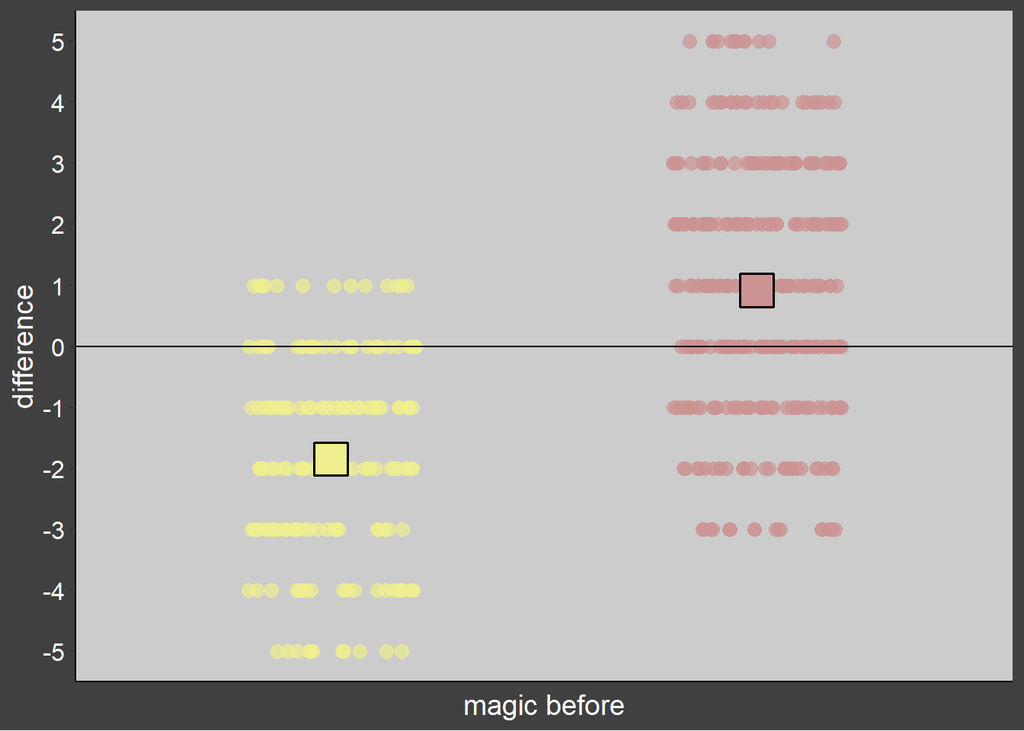

```
##
##  Welch Two Sample t-test
##
## data:  dd$diff by dd$magic_before
## t = 16.004, df = 387.68, p-value < 2.2e-16
## alternative hypothesis: true difference in means is not equal to 0
## 95 percent confidence interval:
##  2.426203 3.105794
## sample estimates:
## mean in group 0 mean in group 1
##       0.9216867      -1.8443114
```

```
##
## Cohen's d
##
## d estimate: 1.434462 (large)
## 95 percent confidence interval:
##    lower    upper
## 1.227818 1.641105
```

```r
dd %>%
  mutate(magic_before = ifelse(magic_before == 0, "no magic", "magic")) %>%
  ggplot(aes(x = factor(magic_before), y = diff, colour = factor(magic_before),
             fill = factor(magic_before))) +
  geom_point(position = position_jitter(width = .2, height = 0), alpha = .7, size = 3) +
  stat_summary(size = 2, fun = "mean", shape = 22, colour = "black") +
  geom_hline(yintercept = 0) +
  labs(y = "difference", x = "magic before") +
  scale_y_continuous(breaks = seq(-5, 5, 1)) +
  scale_colour_manual(values = c("#efef8f", "#cc9393")) +
  scale_fill_manual(values = c("#efef8f", "#cc9393")) +
  julis_theme +
  theme(axis.text.x = element_blank(),
        axis.ticks.x = element_blank())
```

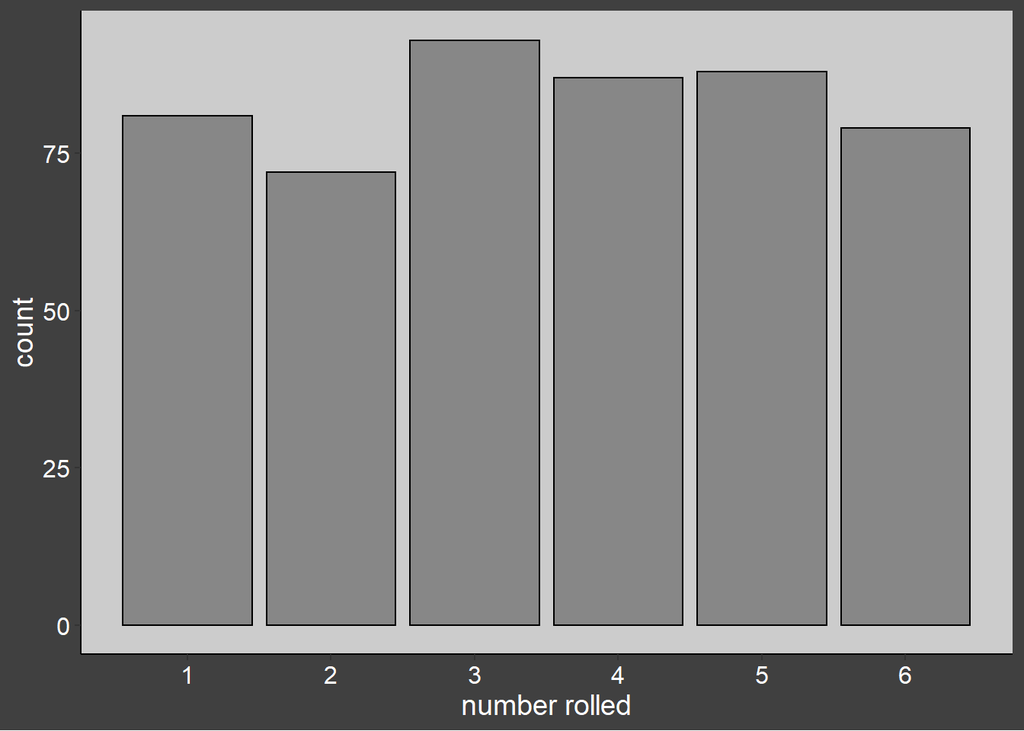

```r
dd %>%
  ggplot(aes(x = roll)) +
  geom_bar(col = "black", alpha = .6) +
  scale_x_continuous(breaks = seq(1, 6, 1)) +
  labs(x = "number rolled", y = "count") +
  julis_theme
```

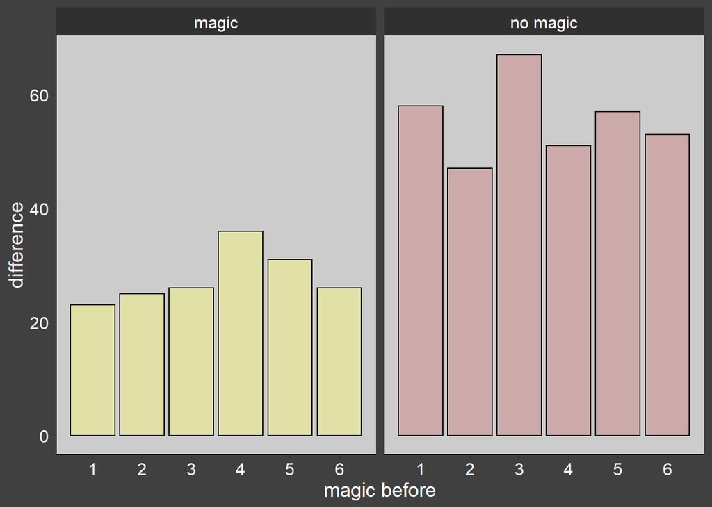

```r
dd %>%
  mutate(magic_before = ifelse(magic_before == 0, "no magic", "magic")) %>%
  ggplot(aes(x = roll, fill = magic_before)) +
  geom_bar(col = "black", alpha = .6) +
  scale_x_continuous(breaks = seq(1, 6, 1)) +
  labs(y = "difference", x = "magic before") +
  scale_colour_manual(values = c("#efef8f", "#cc9393")) +
  scale_fill_manual(values = c("#efef8f", "#cc9393")) +
  facet_wrap(~magic_before) +
  julis_theme
```

So, while it sadly turns out that I do not have magic powers, this example code might have the almost-magic ability to illustrate regression to the mean.